# WeRateDogs act_report

## WeRateDogs act_report

### Introduction

> WeRateDogs is a twitter account that rates people's dogs with humorous comment about dogs, has 4million followers and has received international recognition. With the help of Udacity, I gathered WeRateDogs twitter archive data. It was in 3 different datasets, the enhanced twitter archive, image description file and the tweet json txt file.

> This real world data is hardly clean and therefore a wrangling process is performed to ensure data quality and tidiness which I did for the WeRateDogs project. I then analyzed and visualized the data as shown below:

### Distribution of Rating

> The diagram shows the rating distribution which is skewed to the left with high rating ranging between 9 and 13.

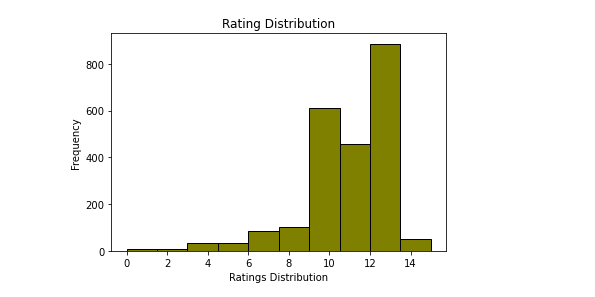

### Most used Twitter Source

> The diagram clearly shows that the most used twitter source is the Iphone, then Vine, third being twitter for web client and the least used source is the tweetdeck.

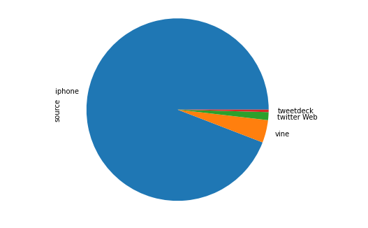

### Most Rated Dog stage

- The most rated dog stage is the doggo puppo, followed by puppo, floofer and the doggo. The diagram show the doggo puppo with the highest rating of over 12.

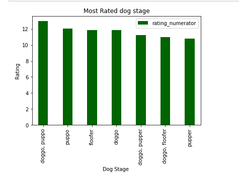

### 10 Most Popular Dog breeds

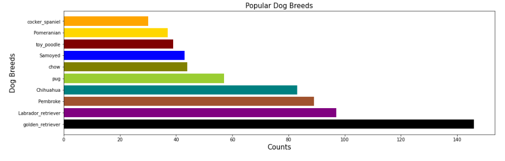

> Golden retriever is the most popular dog breed. Other popular dog breeds are labrador retriever, pembroke, chihuahua while the least famous breeds are pomeranian and cocker spanier.

### Correlation between Retweet count and Favorite

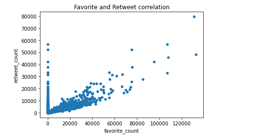

- The scatterplot above shows, there is a positive correlation between the Favorite count and the retweet count which means when one of the favorite increases the retweet count increase too. There is a positive connection between the two variables.